# Data Science in R Specialization - Capstone Project

Week 2 N-Gram Analysis Using `Quanteda` Package

Ken Wood

10/11/2020

### Instructions

1. Demonstrate that we’ve downloaded the data and have successfully loaded it in.
2. Create a basic report of summary statistics about the data sets.
3. Report any interesting findings that we have amassed so far.
4. Get feedback on our plans for creating a prediction algorithm and Shiny app.

### Considerations for the Analysis

1. **Loading the data in.** This dataset is fairly large. We don’t necessarily need to load the entire dataset in to build our algorithms (see point 2 below). At least initially, we might want to use a smaller subset of the data. Reading in chunks or lines using R’s readLines or scan functions can be useful.
2. **Sampling.** To build our models we don’t need to load in and use all of the data. Often relatively few randomly selected rows or chunks need to be included to get an accurate approximation to results that would be obtained using all the data. We might want to create a separate sub-sample dataset by reading in a random subset of the original data and writing it out to a separate file. That way, we can store the sample and not have to recreate it every time. We can use the rbinom function to “flip a biased coin” to determine whether we sample a line of text or not.

### Review Criteria

1. Does the link lead to an HTML page describing the exploratory analysis of the training data set?
2. Has the data scientist done basic summaries of the three files? Word counts, line counts and basic data tables?
3. Has the data scientist made basic plots, such as histograms to illustrate features of the data?
4. Was the report written in a brief, concise style, in a way that a non-data scientist manager could appreciate?

### Load the necessary R packages…

```r
library(R.utils)     # various R programming facilities
library(ggplot2)     # ggplot plotting package
library(dplyr)       # data manipulation utilities
library(quanteda)    # quantitative text analysis package
# library(ngram)       # R package for constructing n-grams (“tokenizing”), as well as                           generating new text based on the n-gram structure of a given                             text input (“babbling”)
# library(slam)        # sparse lightweight arrays and matrices
# library(tidytext)    # tidy text mining package
# library(textmineR)   # functions for text mining and topic modeling
# library(tau)         # text analysis utilities
# library(stringi)     # character string processing package
# library(readtext)
# library(tm)          # text mining package
# library(RWeka)       # a collection of machine learning algorithms for data mining tasks written in Java
# library(SnowballC)   # a R interface to the C 'libstemmer' library that implements Porter's word stemming algorithm for collapsing words to a common root to aid comparison of vocabulary.
```

```r
blogs <- "final/en_US/en_US.blogs.txt"
news <- "final/en_US/en_US.news.txt"
twitter <- "final/en_US/en_US.twitter.txt"
```

### Analysis for `en_US.blogs.txt`

```r
blog_line <- readLines(blogs,encoding="UTF-8", skipNul = TRUE)
blog_corpus <- corpus(blog_line)
num_blog_entries <- sapply(blogs,countLines)  # count number of entries in file
print(paste("Number of entries - blogs: ",num_blog_entries))
```

```
## [1] "Number of entries - blogs:  899288"
```

```r
print(paste("Number of sentences - blogs: ",sum(nsentence(blog_corpus))))
```

```
## [1] "Number of sentences - blogs:  2362935"
```

```r
print(paste("Number of tokens - blogs: ",sum(ntoken(blog_corpus,remove_punct=TRUE))))
```

```
## [1] "Number of tokens - blogs:  37339814"
```

### Analysis for `en_US.news.txt`

```r
news_line <- readLines(news,encoding="UTF-8", skipNul = TRUE)
news_corpus <- corpus(news_line)
num_news_entries <- sapply(news,countLines)   # count number of lines in file
print(paste("Number of entries - news: ",num_news_entries))
```

```
## [1] "Number of entries - news:  1010242"
```

```r
print(paste("Number of sentences - news: ",sum(nsentence(news_corpus))))
```

```
## [1] "Number of sentences - news:  1992553"
```

```r
print(paste("Number of tokens - news: ",sum(ntoken(news_corpus,remove_punct=TRUE))))
```

```
## [1] "Number of tokens - news:  34376642"
```

### Analysis for `en_US.twitter.txt`

```r
twitter_line <- readLines(twitter,encoding="UTF-8", skipNul = TRUE)
twitter_corpus <- corpus(twitter_line)
num_twitter_entries <- sapply(twitter,countLines)   # count number of lines in file
print(paste("Number of entries - twitter: ",num_twitter_entries))
```

```
## [1] "Number of entries - twitter:  2360148"
```

```r
print(paste("Number of sentences - twitter: ",sum(nsentence(twitter_corpus))))
```

```
## [1] "Number of sentences - twitter:  3754216"
```

```r
print(paste("Number of tokens - twitter: ",sum(ntoken(twitter_corpus,remove_punct=TRUE))))
```

```
## [1] "Number of tokens - twitter:  30162656"
```

### Create a sample dataset using 10% each of the `.txt` files

```r
set.seed(42)

data.sample <- c(blog_line[sample(1:length(blog_line),length(blog_line)*0.1)],
                 news_line[sample(1:length(news_line),length(news_line)*0.1)],
                 twitter_line[sample(1:length(twitter_line),length(twitter_line)*0.1)] )
```

#### Remove `blog_line`,`news_line` and `twitter_line` files and associated corpora to free up memory since we don’t need them anymore.

```r
rm(list=c("blog_line","news_line","twitter_line","blog_corpus","news_corpus","twitter_corpus"))
```

### Create the sample corpus and clean it using the `quanteda` package…

```r
sample_corpus <-  corpus(data.sample)
sample_tokens <- tokens(sample_corpus,what = "word",
                        remove_punct = TRUE,
                        remove_symbols = TRUE,
                        remove_numbers = TRUE,
                        remove_url = TRUE,
                        remove_separators = TRUE,
                        split_hyphens = FALSE,
                        include_docvars = TRUE,
                        padding = FALSE)
sample_tokens <- tokens_tolower(sample_tokens)
sample_tokens <- tokens_wordstem(sample_tokens,
                                 language = quanteda_options("language_stemmer"))
sample_tokens <- tokens_select(sample_tokens, pattern = stopwords("en"), selection = "remove")
```

#### Create a plotting function for the n-grams…

```r
n_grams_plot <- function(n, data) {

  # use `reorder` function to sort the words in decreasing frequency
  ggplot(data, aes(x=reorder(feature,-frequency,sum), y=frequency)) +
    geom_bar(stat="Identity") +
    theme(axis.text.x = element_text(angle = 90, hjust = 1)) + xlab(paste(n,"- grams")) +
    ylab("Frequency") + ggtitle(paste(n,"- gram Frequencies")) +
                                  theme(plot.title = element_text(hjust = 0.5))
}
```

#### Let’s get the word frequency distribution for the top 15 most occurring words…

```r
dfm_sample_tokens <- dfm(sample_tokens)
one_gram_freq <- textstat_frequency(dfm_sample_tokens)
head(one_gram_freq, 15)
```

```
##    feature frequency rank docfreq group
## 1      one     30938    1   27084   all
## 2     said     30764    2   27951   all
## 3     just     30693    3   28470   all
## 4     like     30349    4   27076   all
## 5      get     29908    5   27045   all
## 6       go     26736    6   24096   all
## 7     time     25987    7   23174   all
## 8      can     25089    8   22226   all
## 9      day     22450    9   20099   all
## 10    year     21639   10   18841   all
## 11    love     20412   11   18122   all
## 12    make     20410   12   18688   all
## 13     new     19413   13   17459   all
## 14    good     18227   14   16928   all
## 15    know     18189   15   16471   all
```

#### Plot the frequencies of 1-grams…

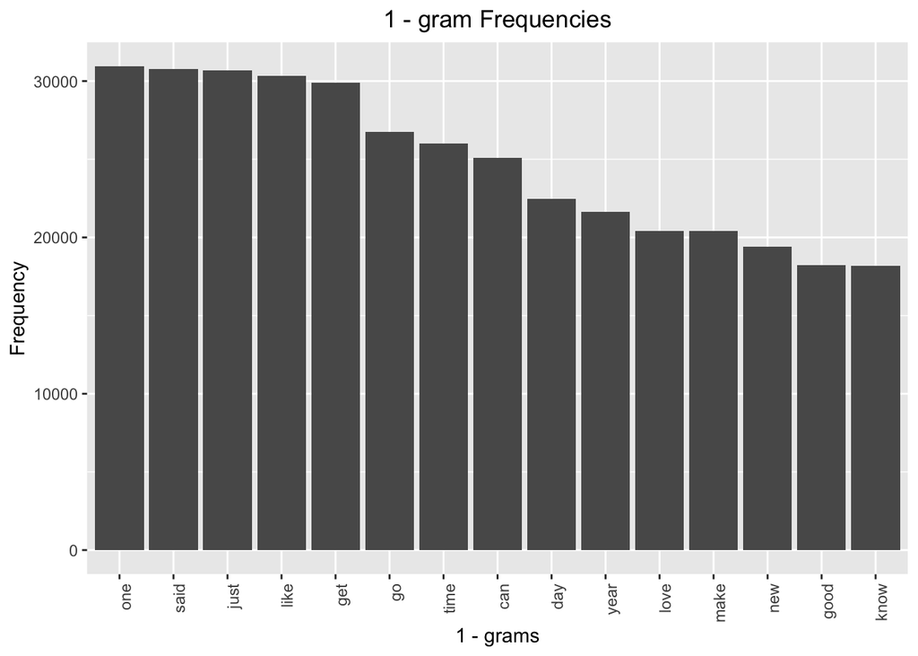

```r
n_grams_plot(1,head(one_gram_freq,15))
```

#### Let’s determine of frequency distribution of 2-grams

```r
two_grams <- dfm(tokens_ngrams(sample_tokens, n = 2))
two_gram_freq <- textstat_frequency(two_grams)
head(two_gram_freq,15)
```

```
##         feature frequency rank docfreq group
## 1     right_now      2463    1    2424   all
## 2     last_year      2284    2    2223   all
## 3     look_like      2206    3    2146   all
## 4      new_york      2011    4    1885   all
## 5     feel_like      1752    5    1702   all
## 6  look_forward      1736    6    1706   all
## 7    last_night      1683    7    1660   all
## 8      year_ago      1654    8    1619   all
## 9   high_school      1477    9    1373   all
## 10    last_week      1420   10    1398   all
## 11 thank_follow      1247   11    1247   all
## 12   first_time      1206   12    1180   all
## 13    make_sure      1194   13    1158   all
## 14      can_get      1106   14    1096   all
## 15      st_loui       956   15     865   all
```

#### Plot the frequencies of 2-grams…

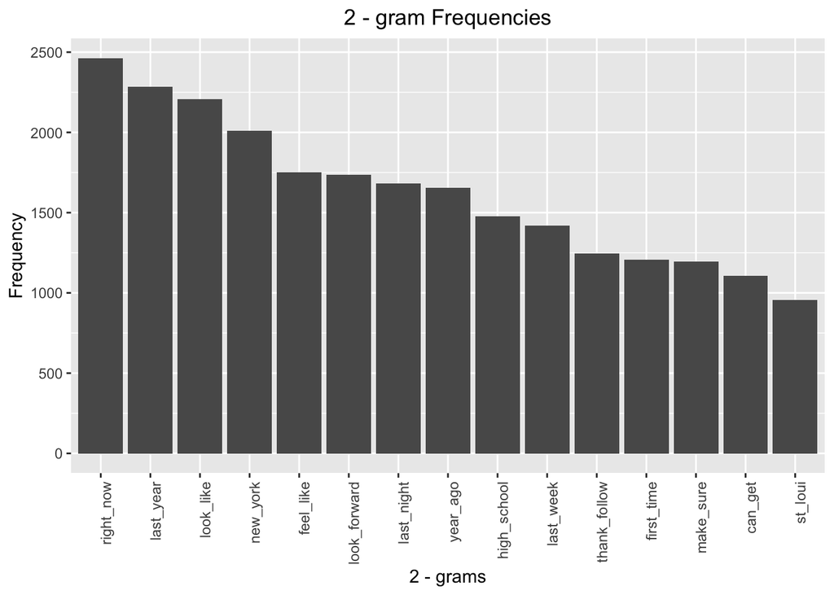

```r
n_grams_plot(2,head(two_gram_freq,15))
```

#### Let’s determine of frequency distribution of 3-grams

```r
three_grams <- dfm(tokens_ngrams(sample_tokens, n = 3))
three_gram_freq <- textstat_frequency(three_grams)
head(three_gram_freq,15)
```

```
##                feature frequency rank docfreq group
## 1     happi_mother_day       375    1     373   all
## 2        new_york_citi       275    2     272   all
## 3          let_us_know       255    3     255   all
## 4       happi_new_year       214    4     214   all
## 5  presid_barack_obama       188    5     188   all
## 6     look_forward_see       165    6     164   all
## 7         two_year_ago       162    7     161   all
## 8          amp_amp_amp       157    8       1   all
## 9        new_york_time       154    9     151   all
## 10       cinco_de_mayo       141   10     136   all
## 11        world_war_ii       123   11     119   all
## 12      st_loui_counti       122   12     118   all
## 13   gov_chris_christi       115   13     114   all
## 14     dream_come_true       107   14     107   all
## 15     first_time_sinc       102   15     102   all
```

#### Plot the frequencies of 3-grams…

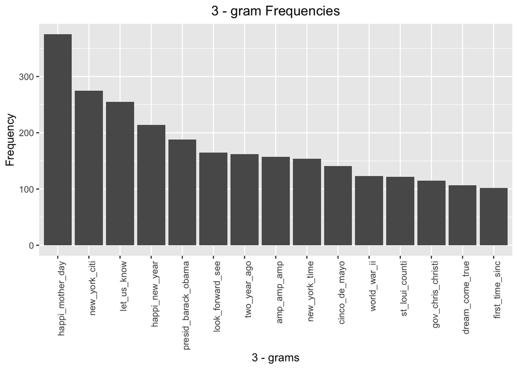

```r
n_grams_plot(3,head(three_gram_freq,15))
```

#### Let’s determine the frequency distribution of 4-grams

```r
four_grams <- dfm(tokens_ngrams(sample_tokens, n = 4))
four_gram_freq <- textstat_frequency(four_grams)
head(four_gram_freq,15)
```

```
##                      feature frequency rank docfreq group
## 1             amp_amp_amp_gt        59    1       1   all
## 2       happi_mother_day_mom        52    2      52   all
## 3            amp_amp_amp_amp        52    2       1   all
## 4      martin_luther_king_jr        51    4      50   all
## 5   amazon_servic_llc_amazon        48    5      24   all
## 6       servic_llc_amazon_eu        48    5      24   all
## 7             amp_amp_amp_lt        46    7       1   all
## 8            amp_amp_lt_span        46    7       1   all
## 9  thank_follow_look_forward        42    9      42   all
## 10             g_fat_g_satur        40   10      40   all
## 11      happi_st_patrick_day        36   11      36   all
## 12     g_protein_g_carbohydr        33   12      33   all
## 13            s_o_new_follow        32   13      32   all
## 14         dure_world_war_ii        32   13      32   all
## 15      make_dream_come_true        31   15      31   all
```

#### Plot the frequencies of 4-grams…

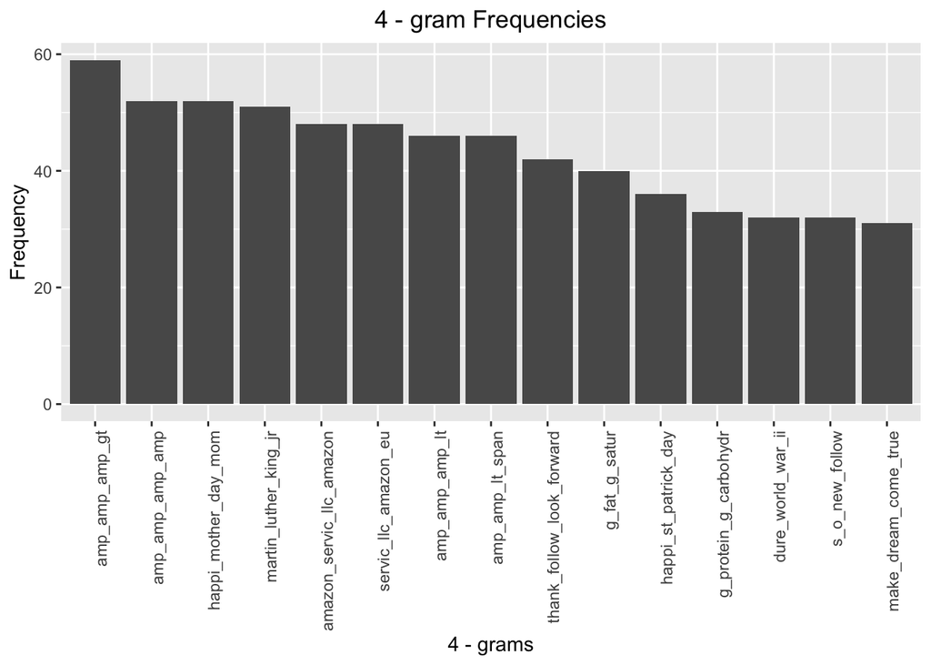

```r
n_grams_plot(4,head(four_gram_freq,15))
```

#### Let’s determine the frequency distribution of 5-grams

```r
five_grams <- dfm(tokens_ngrams(sample_tokens, n = 5))
five_gram_freq <- textstat_frequency(five_grams)
head(five_gram_freq,15)
```

```
##                                 feature frequency rank docfreq group
## 1           amazon_servic_llc_amazon_eu        48    1      24   all
## 2                   amp_amp_amp_lt_span        46    2       1   all
## 3                   amp_amp_amp_amp_amp        41    3       1   all
## 4               g_protein_g_carbohydr_g        31    4      31   all
## 5   style_background_none_repeat_scroll        30    5       1   all
## 6  background_none_repeat_scroll_yellow        30    5       1   all
## 7       none_repeat_scroll_yellow_class        29    7       1   all
## 8     span_style_background_none_repeat        29    7       1   all
## 9                   span_amp_amp_amp_gt        28    9       1   all
## 10   content_provid_subject_chang_remov        25   10      25   all
## 11       provid_subject_chang_remov_ani        25   10      25   all
## 12         subject_chang_remov_ani_time        25   10      25   all
## 13    particip_amazon_servic_llc_amazon        24   13      24   all
## 14          servic_llc_amazon_eu_associ        24   13      24   all
## 15        llc_amazon_eu_associ_programm        24   13      24   all
```

#### Plot the frequencies of 5-grams…

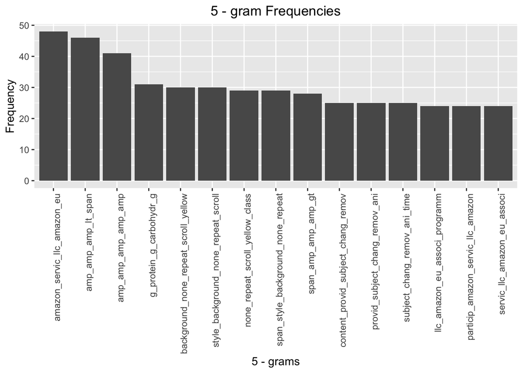

```r
n_grams_plot(5,head(five_gram_freq,15))
```